# Week 2. Introduction to R (III)

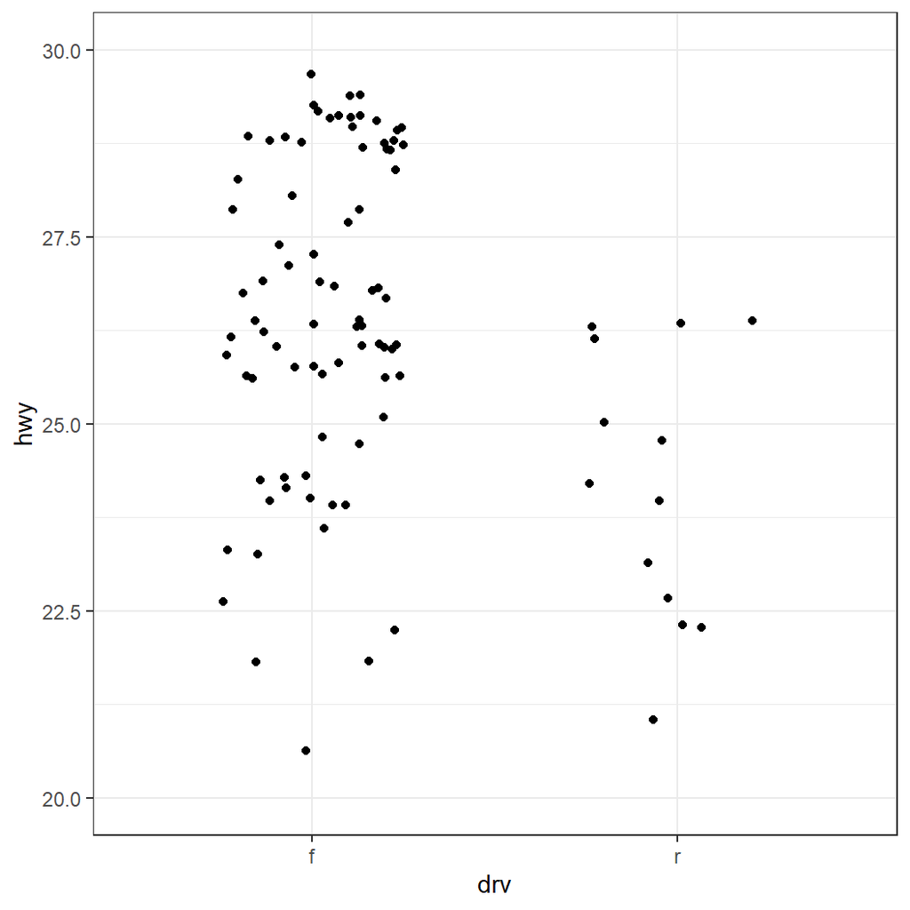

```r
## 구동 종류를 두 가지로 줄이고, hwy도 20부터 30으로 값을 줄이겠습니다.
ggplot(mpg, aes(drv, hwy)) +
  geom_jitter(width = 0.25) +
  lims(x = c("f", "r"), y = c(20, 30)) +
  theme_bw()
```

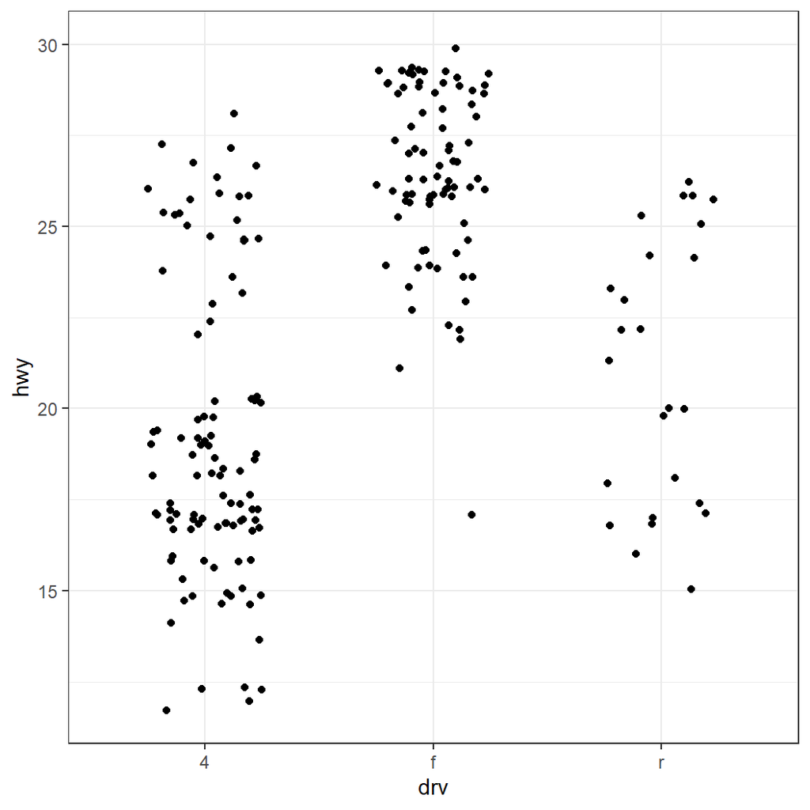

```r
## 연속형 변수일 경우, 한쪽만 제한(상한선, 하한선)하고 싶을 때는 NA를 이용합니다. 아래는 상한만 30으로 설정한 경우입니다.
ggplot(mpg, aes(drv, hwy)) +
  geom_jitter(width = 0.25, na.rm = TRUE) +
  ylim(NA, 30) + theme_bw()
```

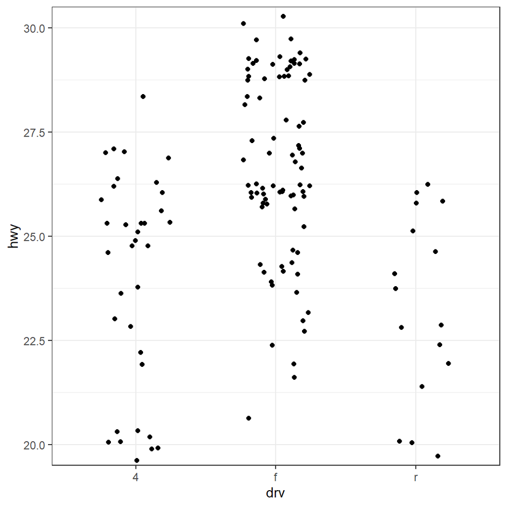

```r
## 만약 플롯의 특정한 부분만 자세히 살펴보려면 coord_cartisian()이라는 함수를 이용할 수 있습니다.
ggplot(mpg, aes(drv, hwy)) +
  geom_jitter(width = 0.25) +
  coord_cartesian(y = c(20, 30)) + theme_bw()
```

여기서 한 가지 팁은 `directlabels`라는 패키지입니다. 이 패키지를 이용하면 범례를 이용하지 않고도 더 깔끔한 여러 가지 색상을 이용할 수 있습니다.

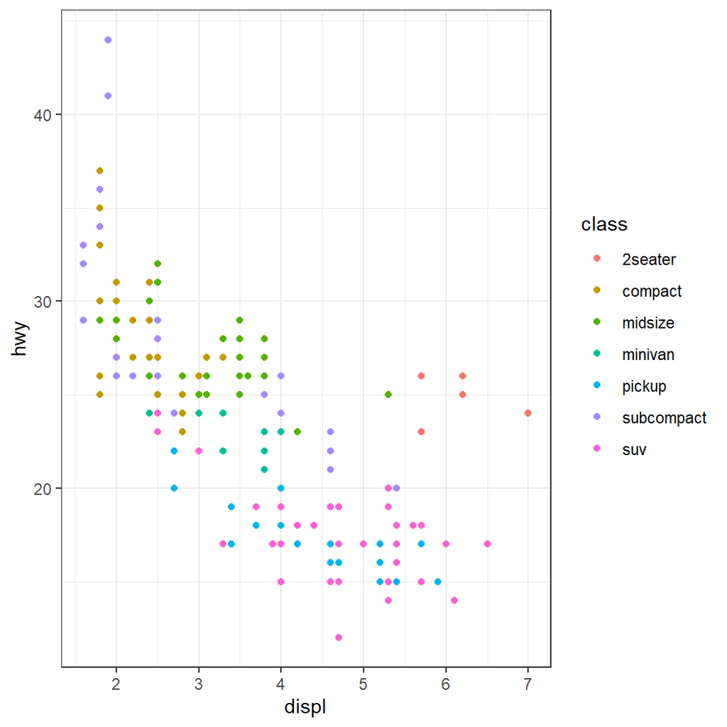

```r
# install.packages('directlabels')
ggplot(mpg, aes(displ, hwy, colour = class)) +
  geom_point() + theme_bw()
```

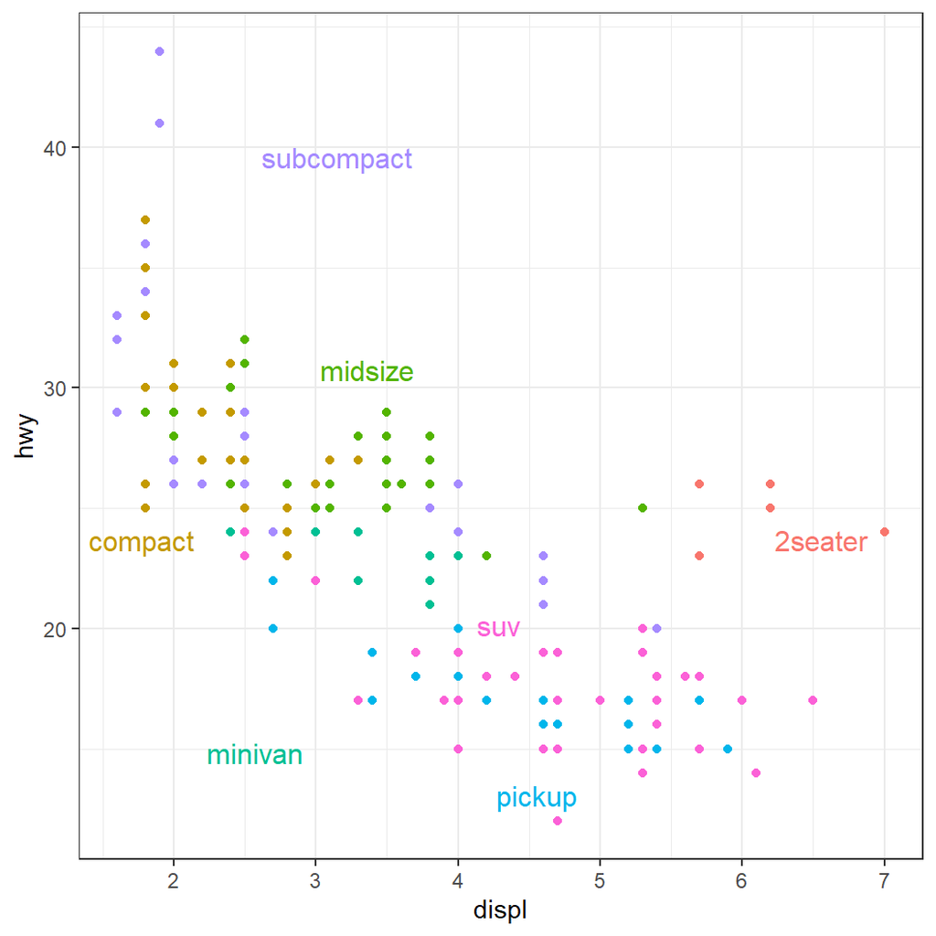

```r
ggplot(mpg, aes(displ, hwy, colour = class)) +
  geom_point(show.legend = FALSE) +
  directlabels::geom_dl(aes(label = class), method = "smart.grid") +
  theme_bw()
```

플롯에 우리가 필요로 하는 정보를 기록할 수 있습니다. `annotation`이라고 하는데요.

- `geom_text()는 텍스트를 직접 플롯에 덧붙이거나 혹은 특정 한 점 관측치에 레이블을 새길 때 주로 사용합니다. 이탈치나 어떤 중요한 의미를 가지는 관측치에 한에서 레이블을 달아주면 플롯에 이해가 쉬워집니다.
- `geom_rect()`은 플롯에서 관심있는 부분을 사각형의 형태로 하이라이트 해줄 수 있습니다.
- `geom_rect()`는 `xmin`, `xmax`, `ymin`, `ymax`와 같은 미학요소들을 이용해서 사각형을 그릴 수 있습니다.
- `geom_line()`, `geom_path()`, 그리고 `geom_segment()`는 선을 덧그리는 데 사용됩니다.
  - 이 세 `geom` 함수들은 모두 화살표 요소를 가지고 있어서 선 끝에 화살표를 달 수 있습니다. `arrow()` 함수가 바로 그것입니다. `angle()`, `length()`, `end()`, `type()` 등으로 다양한 길이와 모양의 화살표를 그릴 수 있습니다.
- `geom_vline()`, `geom_hline()`, 그리고 `geom_abline()`은 일종의 기준선을 그릴 수 있게 도와줍니다.

```r
glimpse(economics)
```

```
## Rows: 574
## Columns: 6
## $ date     <date> 1967-07-01, 1967-08-01, 1967-09-01, 1967-10-01, 1967-11-0...
## $ pce      <dbl> 506.7, 509.8, 515.6, 512.2, 517.4, 525.1, 530.9, 533.6, 54...
## $ pop      <dbl> 198712, 198911, 199113, 199311, 199498, 199657, 199808, 19...
## $ psavert  <dbl> 12.6, 12.6, 11.9, 12.9, 12.8, 11.8, 11.7, 12.3, 11.7, 12.3...
## $ uempmed  <dbl> 4.5, 4.7, 4.6, 4.9, 4.7, 4.8, 5.1, 4.5, 4.1, 4.6, 4.4, 4.4...
## $ unemploy <dbl> 2944, 2945, 2958, 3143, 3066, 3018, 2878, 3001, 2877, 2709...
```

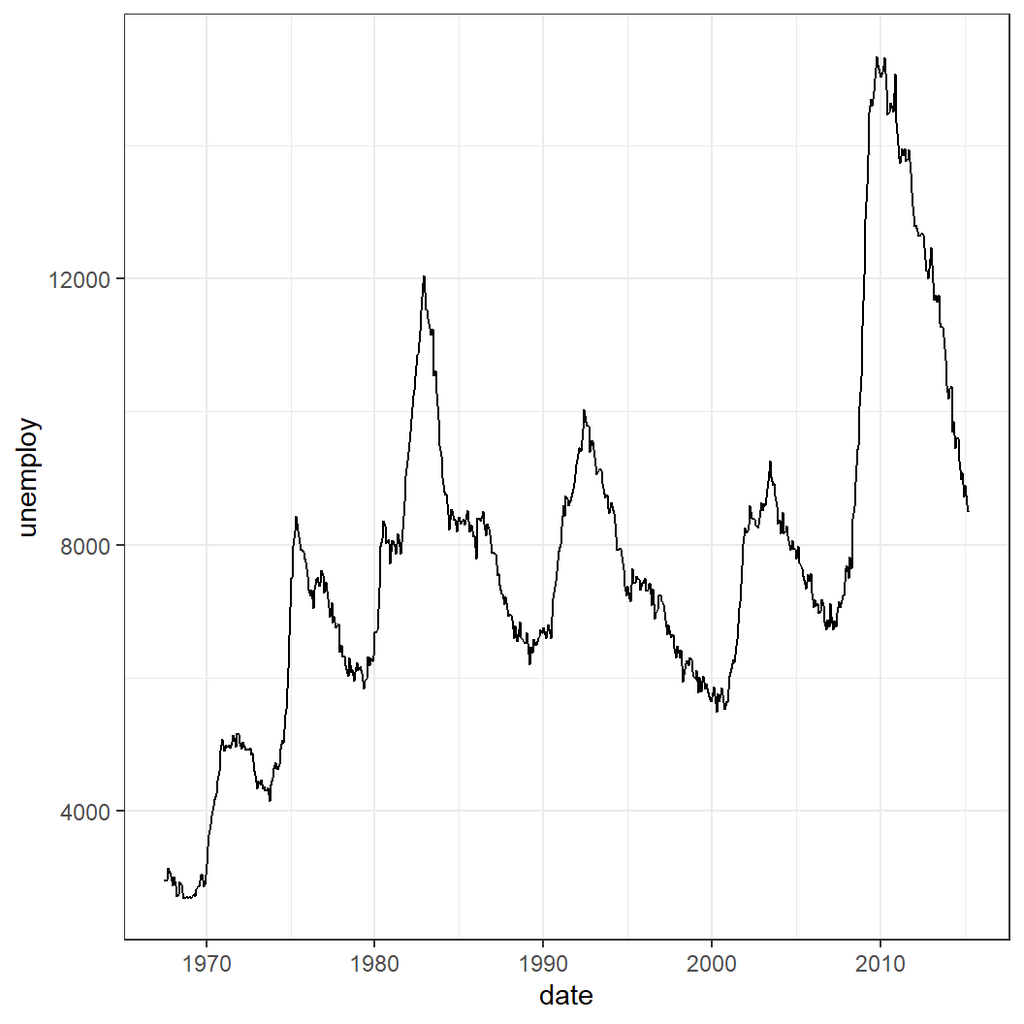

```r
## 시간의 흐름에 따른 미국의 실업자 수의 변화를 나타내보겠습니다.
ggplot(economics, aes(date, unemploy)) +
  geom_line() + theme_bw()
```

```r
## 미국 대통령의 재임기간입니다.
presidential <- presidential %>%
  dplyr::filter(start > economics$date[1])
presidential
```

| name | start | end | party |
| --- | --- | --- | --- |
| Nixon | 1969-01-20 | 1974-08-09 | Republican |
| Ford | 1974-08-09 | 1977-01-20 | Republican |
| Carter | 1977-01-20 | 1981-01-20 | Democratic |
| Reagan | 1981-01-20 | 1989-01-20 | Republican |
| Bush | 1989-01-20 | 1993-01-20 | Republican |
| Clinton | 1993-01-20 | 2001-01-20 | Democratic |
| Bush | 2001-01-20 | 2009-01-20 | Republican |
| Obama | 2009-01-20 | 2017-01-20 | Democratic |

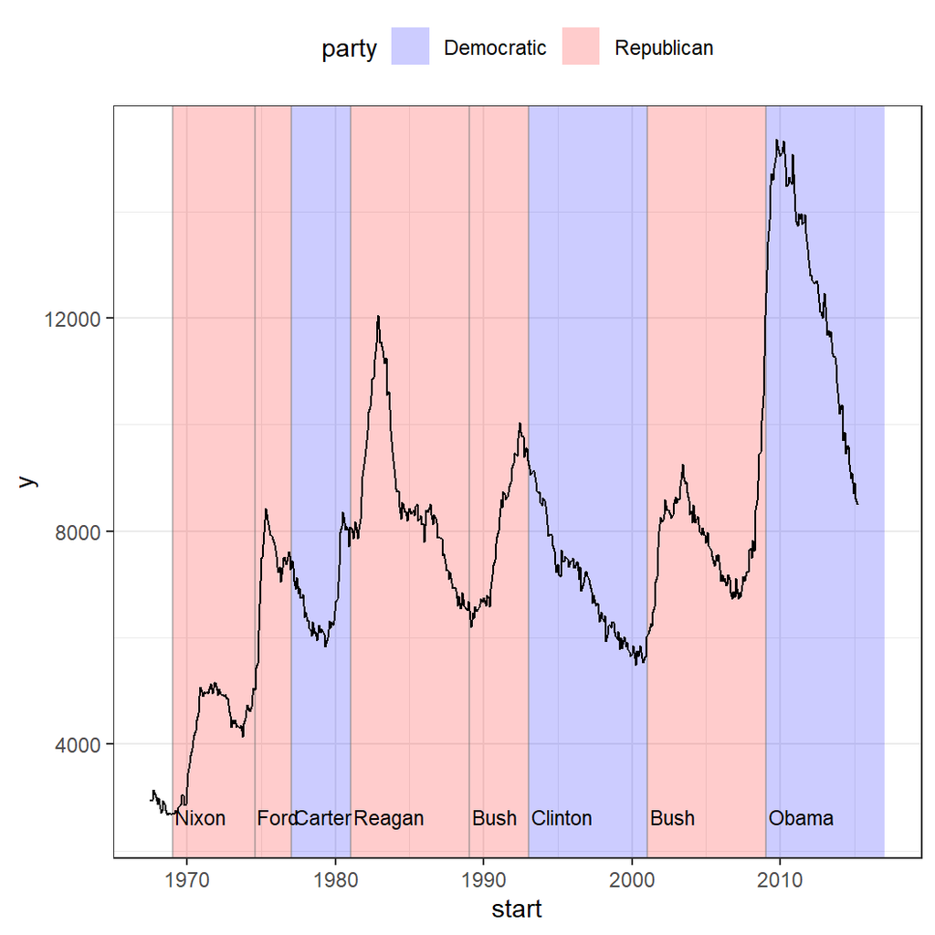

```r
## 이 두 가지 자료를 합해보면 다음과 같습니다.
ggplot(economics) +
  geom_rect(
    aes(xmin = start, xmax = end, fill = party),
    ymin = -Inf, ymax = Inf, alpha = 0.2,
    data = presidential
  ) +
  geom_vline(
    aes(xintercept = as.numeric(start)),
    data = presidential,
    colour = "grey50", alpha = 0.5
  ) +
  geom_text(
    aes(x = start, y = 2500, label = name),
    data = presidential,
    size = 3, vjust = 0, hjust = 0, nudge_x = 50
  ) +
  geom_line(aes(date, unemploy)) +
  scale_fill_manual(values = c("blue", "red")) +
  theme_bw() + theme(legend.position = "top")
```

우리는 `geom`을 이용해서 데이터 하나를 가지고 여러 가지 층위를 덧씌워 다양한 정보를 가진 플롯으로 재생산할 수 있습니다.

이제까지는 개별 `geom`을 하나씩 적용해서 살펴보았습니다만, 이 `geom`들을 하나의 `ggplot` 내에서 동시에 집합적으로 사용할 수 있습니다.

```r
data(Oxboys, package = 'nlme')
df <- as_tibble(Oxboys)
df
```

| Subject | age | height | Occasion |
| --- | --- | --- | --- |
| 1 | -1.0000 | 140.50 | 1 |
| 1 | -0.7479 | 143.40 | 2 |
| 1 | -0.4630 | 144.80 | 3 |
| 1 | -0.1643 | 147.10 | 4 |
| 1 | -0.0027 | 147.70 | 5 |
| 1 | 0.2466 | 150.20 | 6 |
| 1 | 0.5562 | 151.70 | 7 |
| 1 | 0.7781 | 153.30 | 8 |
| 1 | 0.9945 | 155.80 | 9 |
| 2 | -1.0000 | 136.90 | 1 |

[output cut: 224 more lines]

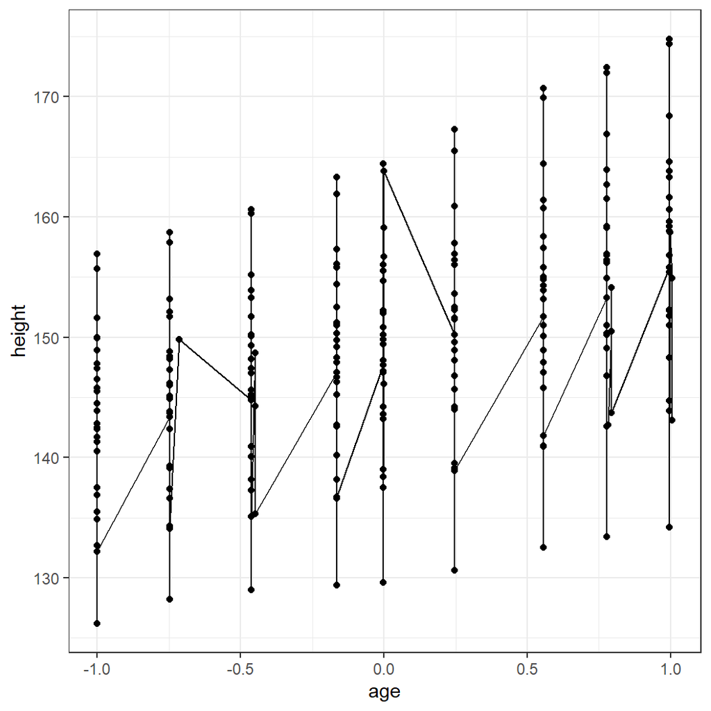

```r
ggplot(Oxboys, aes(age, height)) +
  geom_point() +
  geom_line() + theme_bw()
```

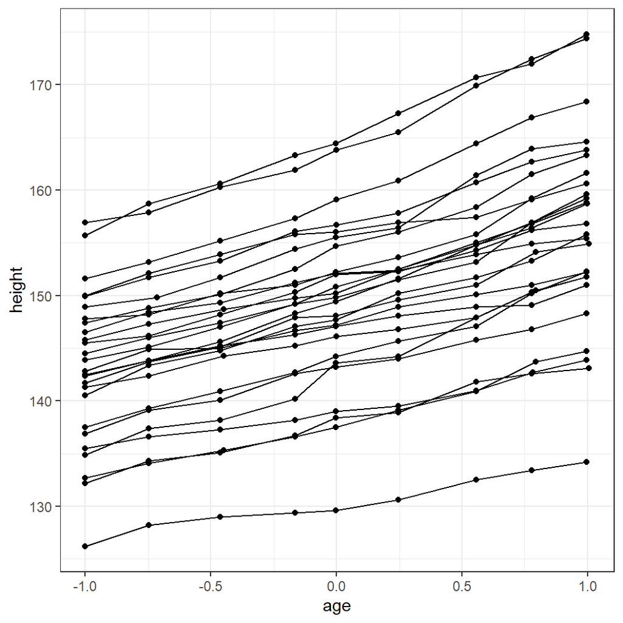

```r
ggplot(Oxboys, aes(age, height, group = Subject)) +
  geom_point() +
  geom_line() + theme_bw()
```

## 척도, 범례

척도는 축과 범례를 만드는 도구로, 데이터를 어떠한 단위로 표현할 것인가에 사용됩니다.

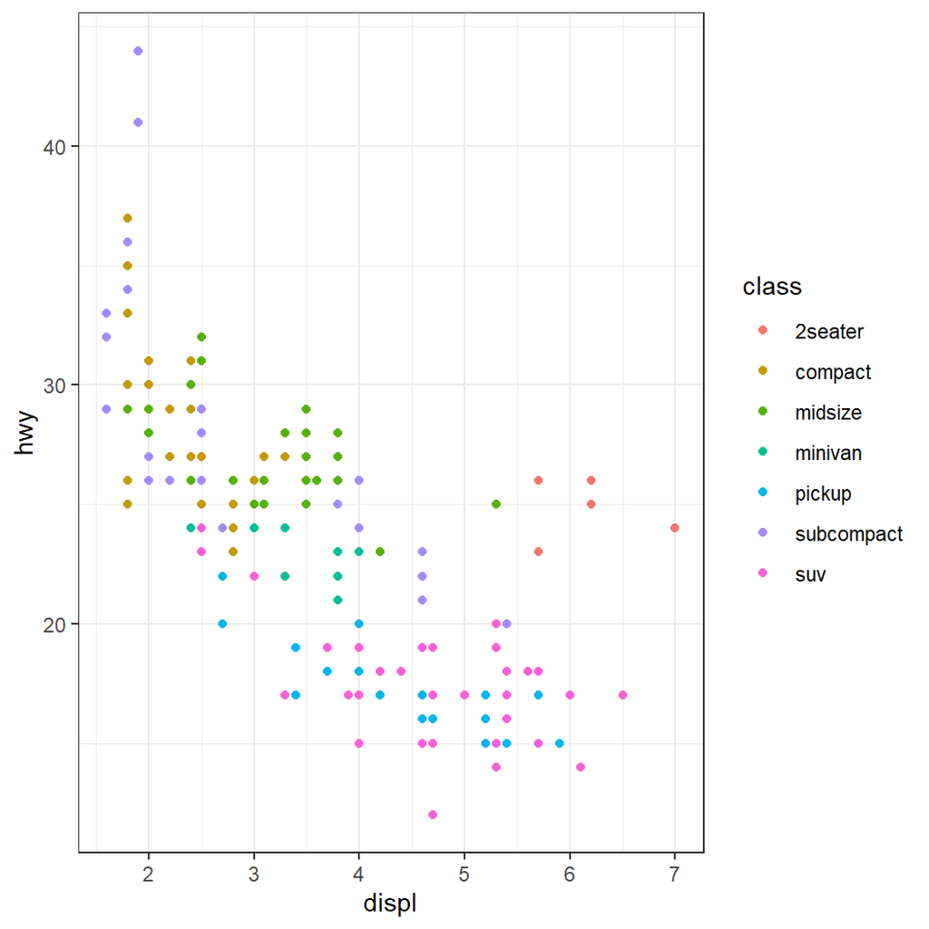

```r
ggplot(mpg, aes(displ, hwy)) +
  geom_point(aes(colour = class)) + theme_bw()
```

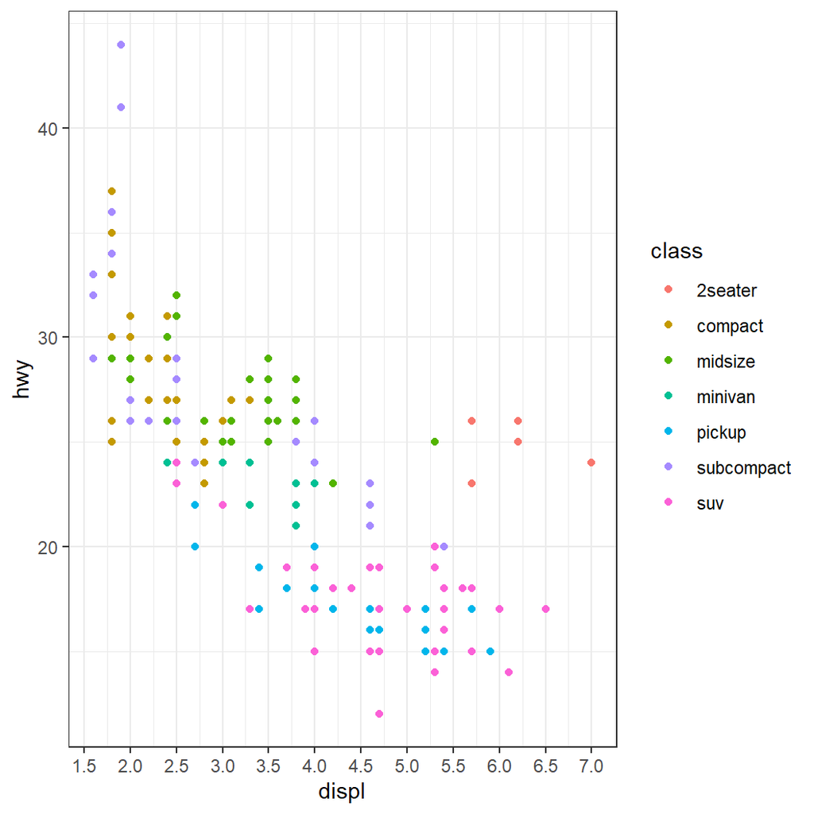

```r
ggplot(mpg, aes(displ, hwy)) +
  geom_point(aes(colour = class)) +
  scale_x_continuous(breaks = c(seq(0, 7, 0.5))) +
  scale_y_continuous() +
  scale_color_discrete() + theme_bw()
```

`scale` 함수를 통해서 원하는 축 제목을 바로 넣을 수도 있습니다.

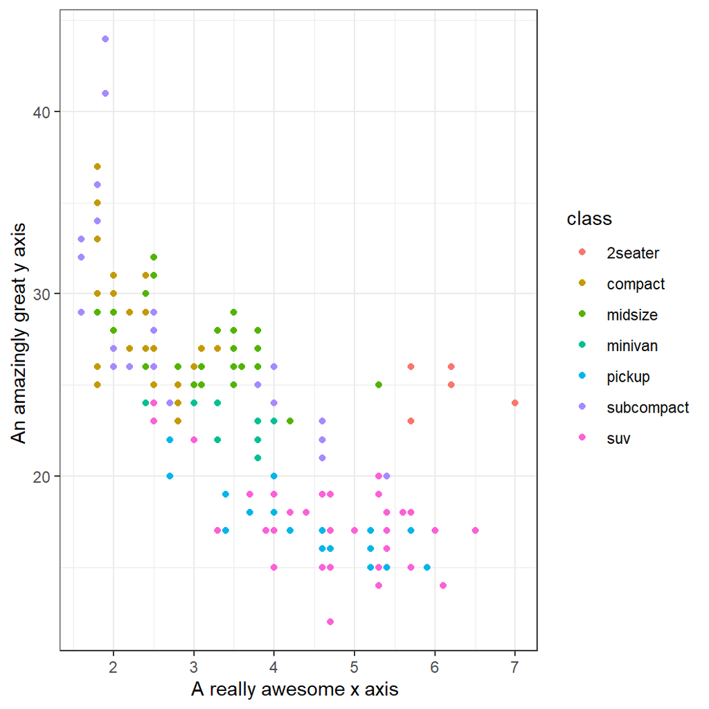

```r
ggplot(mpg, aes(displ, hwy)) +
  geom_point(aes(colour = class)) +
  scale_x_continuous("A really awesome x axis ") +
  scale_y_continuous("An amazingly great y axis ") + theme_bw()
```

`geom`과는 다르게 `scale`에서 `+`를 사용하게 되면 이전에 사용한 `scale`을 덮어쓰게 됩니다.

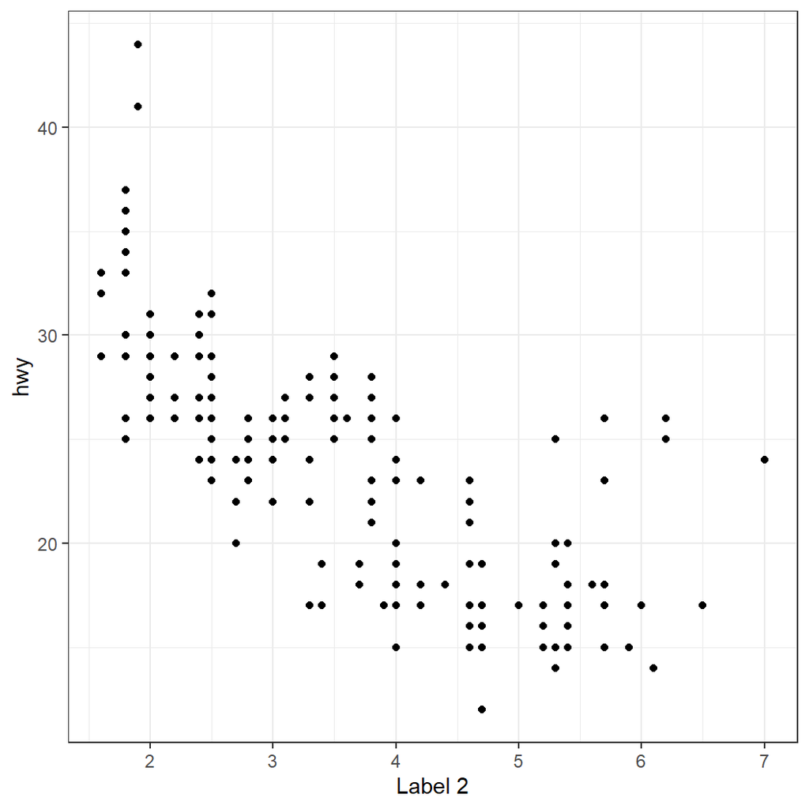

```r
ggplot(mpg, aes(displ, hwy)) +
  geom_point() +
  scale_x_continuous("Label 1") +
  scale_x_continuous("Label 2") + theme_bw()
```

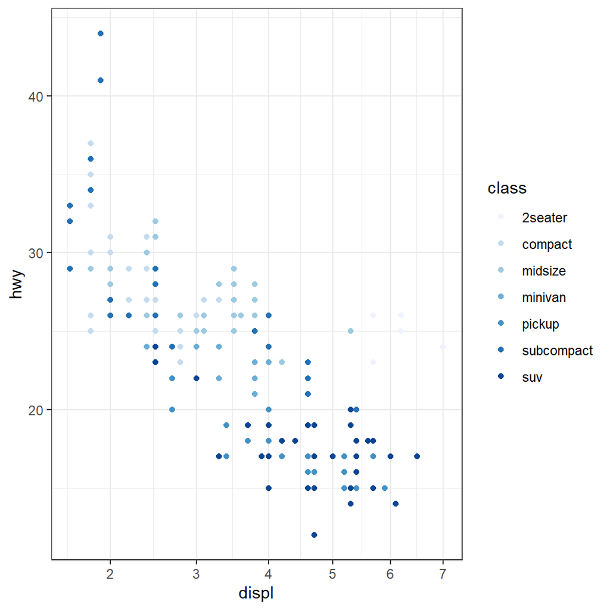

```r
## 서로 다른 스케일을 동시에 사용할 수도 있습니다.
ggplot(mpg, aes(displ, hwy)) +
  geom_point(aes(colour = class)) +
  scale_x_sqrt() +
  scale_colour_brewer() + theme_bw()
```

`scale`은 `_`를 이용해서 세부 함수들이 구성되어 있습니다. 크게 세 부분으로 나뉘는데, 1. `scale` 2. `scale`을 적용할 미학 요소의 이름 (예, `colour`, `shape` 또는 `x`) 3. `scale`의 이름 (예, `continuous`, `discrete`, `brewer`).

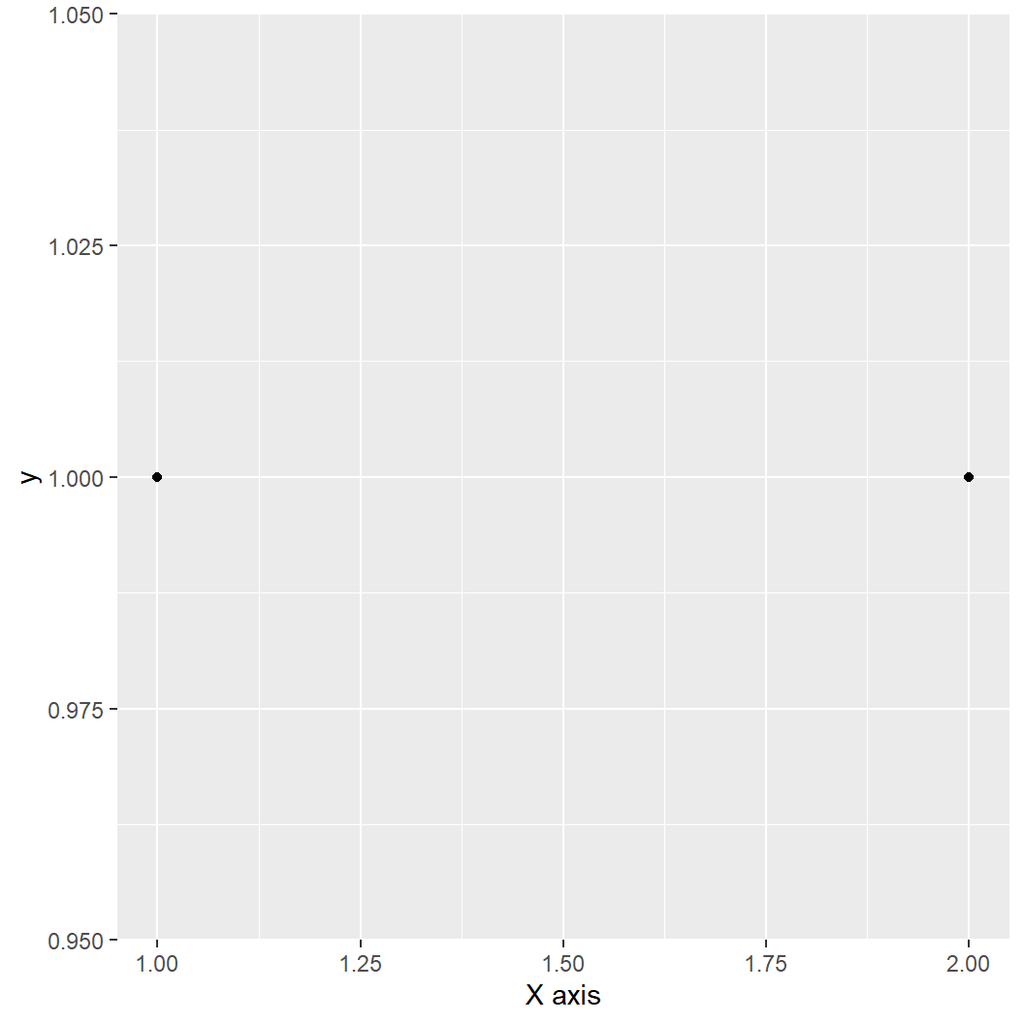

```r
df <- data.frame(x = 1:2, y = 1, z = "a")
p <- ggplot(df, aes(x, y)) + geom_point()
p + scale_x_continuous("X axis")
```

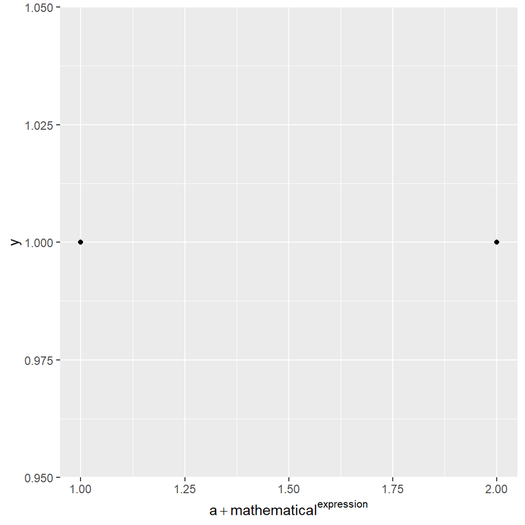

```r
p + scale_x_continuous(quote(a + mathematical ^ expression))
```

한편, `ggplot`에서는 직접적으로 범례를 건드리지는 않습니다. 대신에 데이터를 수정해서 애초에 범례가 원하는 대로 깔끔하게 나오도록 하는 것이 일반적입니다.

우리는 `scales` 패키지를 이용해서 축에 레이블을 다양한 척도로 매길 수 있습니다.

- `scales::comma_format()` 큰 숫자에 자동으로 콤마를 넣어줍니다.
- `scales::unit_format(unit, scale)`은 원래의 `scale`에 단위를 넣어줍니다/
- `scales::dollar_format(prefix, suffix)`은 현재의 값을 소수점 둘째 자리로 반올림해서 달러로 표현해줍니다.
- `scales::wrap format()`은 길이가 긴 레이블을 몇 개의 줄로 줄바꿈해줍니다.
  - axes + scale_y_continuous(labels = scales::percent_format())
  - axes + scale_y_continuous(labels = scales::dollar_format(prefix = “$”))

## 테마

마지막으로 테마 함수는 데이터가 아닌 플롯의 요소들을 관리하는 데 사용됩니다. 플롯의 배경색, 범례 위치, 제목 크기, 글꼴 등을 변경하는 데 사용됩니다.

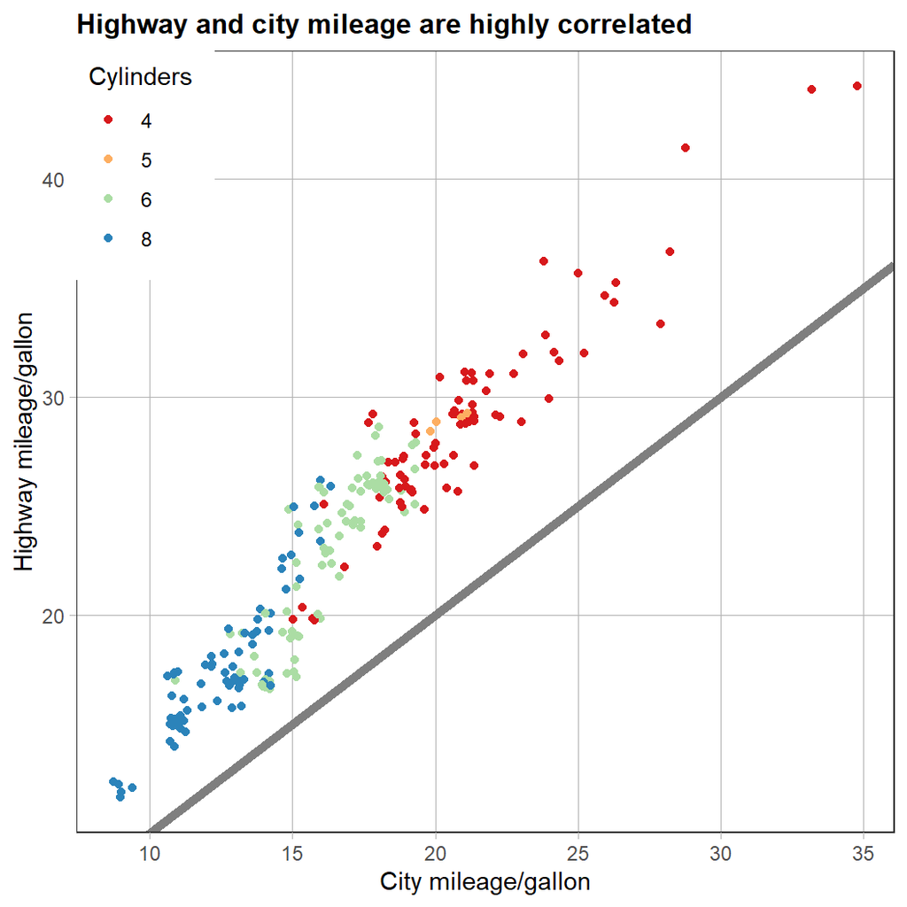

```r
ggplot(mpg, aes(cty, hwy, color = factor(cyl))) + geom_jitter() +
  geom_abline(colour = "grey50", size = 2) +
  labs(
    x = "City mileage/gallon",
    y = "Highway mileage/gallon",
    colour = "Cylinders",
    title = "Highway and city mileage are highly correlated"
  ) +
  scale_colour_brewer(type = "seq", palette = "Spectral") +
  theme_bw() +
  theme(
    plot.title = element_text(face = "bold", size = 12),
    legend.background =
      element_rect(fill = "white", size = 4, colour = "white"),
    legend.justification = c(0, 1),
    legend.position = c(0, 1),
    axis.ticks = element_line(colour = "grey70", size = 0.2),
    panel.grid.major = element_line(colour = "grey70", size = 0.2),
    panel.grid.minor = element_blank()
  )
```

기존에 이미 `ggplot`이 제공하는 테마로는 `theme_bw()`, `theme_linedraw()`, `theme_light()`, `theme_dark()`, `theme_minimal()`, `theme_classic()`, 그리고 `theme_void()` 등이 있습니다. 이외에도 `ggthemes`와 같은 패키지를 통해 추가로 다른 `theme`을 찾아볼 수 있습니다.

마지막으로 `theme`의 개별 요소들을 수정하기 위해서는 다음과 같은 코드를 사용합니다: `plot + theme(element.name = element function())`